# Time Series Homework: Chapter 1 Lesson 5

Tristan Farrow

## Data

```r
vessels <- rio::import("https://byuistats.github.io/timeseries/data/Vessels_Trade_US.csv")
```

**Revisions**

## Questions

### Question 1: Context and Measurement (10 points)

The first part of any time series analysis is context. You cannot properly analyze data without knowing what the data is measuring. Without context, the most simple features of data can be obscure and inscrutable. This homework assignment will center around the series below.

Please research the time series. In the spaces below, give the data collection process, unit of analysis, and meaning of each observation for the series.

#### a) **Vessels Cleared in Foreign Trade for United States**

https://fred.stlouisfed.org/series/M03022USM583NNBR

**Answer**

This is a historical time-series data set that records the monthly volume of boats or other means of transportation cleared in foreign trade for the U.S. in units of tons of per 100 cubit feet. Prior to vessels leaving cargo has to be declared with details of the origin and destination, weight, and general details. This is data was collected by the U.S. Bureau of Foreign and Domestic Commerce and later digitized by the National Bureau of Economic Research.

### Question 2: Seasonally Adjusted Series - Calculation and Plot (10 points)

#### a) Decompose the Vessels Cleared in Foreign Trade series using the mul tiplicative decomposition model. Show the first 10 rows of results from the decomposition as shown in the Time Series Notebook.

**Answer**

```r
vessels_clean <- vessels %>%
  mutate(date2 = dmy(date),
         year_month = yearmonth(date2)
         ) %>%
  select(year_month, vessels)

vessel_ts <- vessels_clean %>%
  tsibble(index = year_month)


vessels_decomp <- vessel_ts %>%
  model(feasts::classical_decomposition(vessels, type = "mult")) %>%
  components() |>
  select(!.model)

head(vessels_decomp, 10)
```

```
# A tsibble: 10 x 6 [1M]
   year_month vessels trend seasonal random season_adjust
        <mth>   <int> <dbl>    <dbl>  <dbl>         <dbl>
 1   1901 Jan    2128   NA     0.794  NA            2679.
 2   1901 Feb    1983   NA     0.743  NA            2670.
 3   1901 Mar    2206   NA     0.834  NA            2645.
 4   1901 Apr    2362   NA     0.908  NA            2601.
 5   1901 May    2792   NA     1.05   NA            2666.
 6   1901 Jun    2742   NA     1.13   NA            2417.
 7   1901 Jul    3159 2606.    1.21    1.00         2612.
 8   1901 Aug    3291 2584.    1.23    1.03         2671.
 9   1901 Sep    2930 2556.    1.13    1.01         2587.
10   1901 Oct    2935 2545.    1.09    1.06         2687.
```

#### b) Illustrate the original, trend, and the seasonally adjusted series in the same plot. Use the appropriate axis labels, units, and captions.

**Answer**

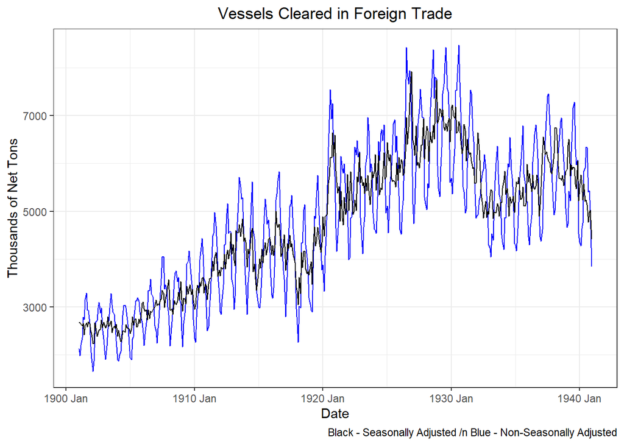

```r
ggplot() +
  geom_line(data = vessels_decomp,aes(x = year_month, y = vessels), color = "blue") +
  geom_line(data = vessels_decomp, aes(x = year_month, y = season_adjust)) +
  labs(
    title = "Vessels Cleared in Foreign Trade",
    x = "Date",
    y = "Thousands of Net Tons",
    caption = "Black - Seasonally Adjusted /n Blue - Non-Seasonally Adjusted"
  ) +
  theme_bw() +
  theme(
    plot.title = element_text(hjust = 0.5)
  )
```

### Question 3: Seasonally Adjusted Series - Analysis (30 points)

#### a) Plot the random component of the multiplicative decomposition from Q2a.

**Answer**

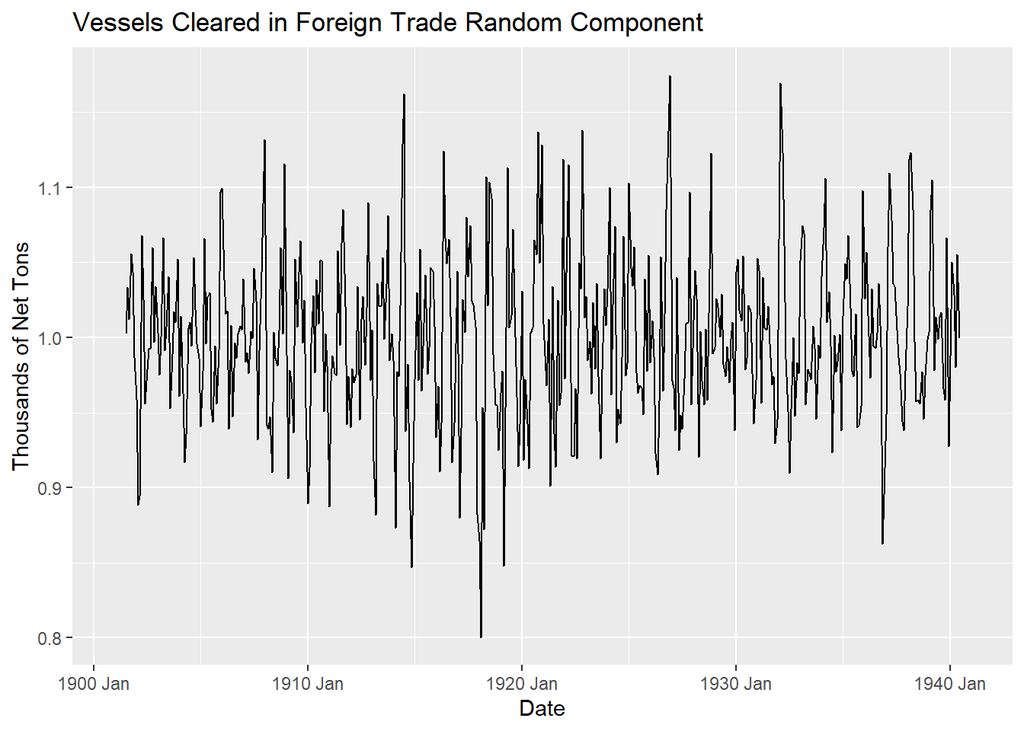

```r
ggplot() +
  geom_line(data = vessels_decomp, aes(x = year_month, y = random)) +
  labs(
    title = "Vessels Cleared in Foreign Trade Random Component",
    x = "Date",
    y = "Thousands of Net Tons"
  )
```

#### b) Use the additive decomposition method to decompose the Vessels Cleared in Foreign Trade series. Plot the random component.

**Answer**

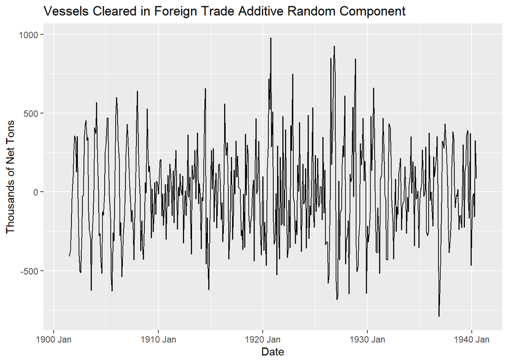

```r
vessel_add_decomp <- vessel_ts %>%
  model(feasts::classical_decomposition(vessels, type = "add")) %>%
  components()

ggplot() +
  geom_line(data = vessel_add_decomp, aes(x = year_month, y = random)) +
  labs(
    title = "Vessels Cleared in Foreign Trade Additive Random Component",
    x = "Date",
    y = "Thousands of Net Tons"
  )
```

#### c) Please describe the differences between the random component series and use it as part of your justification for why we use the multiplicative decomposition model instead of the additive model to seasonally adjust the series.

**Answer**

The multiplicative model assumes that the seasonal variation increases with the trend compared to an additive model where the seasonal variation is constant over time. Comparing the random components above, the multiplicative model random component hovers around 1 and the additive model centers around 0 but has much larger variation.

The larger seasonal swings can not be accounted for by the additive model as they are not constant and so are passed to the random variable explaining the greater variation. The multiplicative model does account for this and retains the greater seasonal effect in the seasonal component leading to less variation in the random component.

## Rubric

[output not shown]